# Divorce/Separation

# 1 Description of DataSchema variable

The description of harmonised variables is the following:

- Short name: `divorce`
- Variable label: `Experience of divorce/separation`
- Domain: `Social environment`
- Value type: `categorical`
- Categories:

| **Code** | **Category Label** |
| --- | --- |
| 0 | No |
| 1 | Yes |

- Category missings:

| **Code** | **Category Label** |
| --- | --- |
| 991 | CAPI/interviewer error |
| 992 | Impute |
| 993 | Disable to measure |
| 994 | Not attempt/not done |
| 995 | Does not answer |
| 996 | Not applicable |
| 997 | Refuse |
| 998 | Do not know |
| 999 | Missing |

# 2 Data process

## 2.1 England

### 2.1.1 Wave 1

#### 2.1.1.1 Study-specific variable description

The study-specific variable elected to be harmonised is:

- Name: `dimar`
- Label: `Subject's current legal marital status`
- Categories:
  - `1 = Single, that is never married`
  - `2 = Married, first and only marriage`
  - `3 = Remarried, second or later marriage`
  - `4 = Legally separated`
  - `5 = Divorced`
  - `6 = Widowed`
- Missings:
  - `-9 = Refusal`
  - `-8 = Don't Know`
  - `-1 = Not applicable`
- Description:

DIMAR

| Sample size | Missing values |
| --- | --- |
| 12099 | 3 |

Category

|  | 1 | 2 | 3 | 4 | 5 | 6 |
| --- | --- | --- | --- | --- | --- | --- |
| Frequency | 672.00 | 6812.0 | 1349.00 | 144.00 | 1116.00 | 2003.00 |
| Percentage | 5.55 | 56.3 | 11.15 | 1.19 | 9.22 | 16.56 |

Type of missing

|  | -9 | -8 | -1 | NA |
| --- | --- | --- | --- | --- |
| Frequency | 2.00 | 1.00 | 0 | 0 |
| Percentage | 0.02 | 0.01 | 0 | 0 |

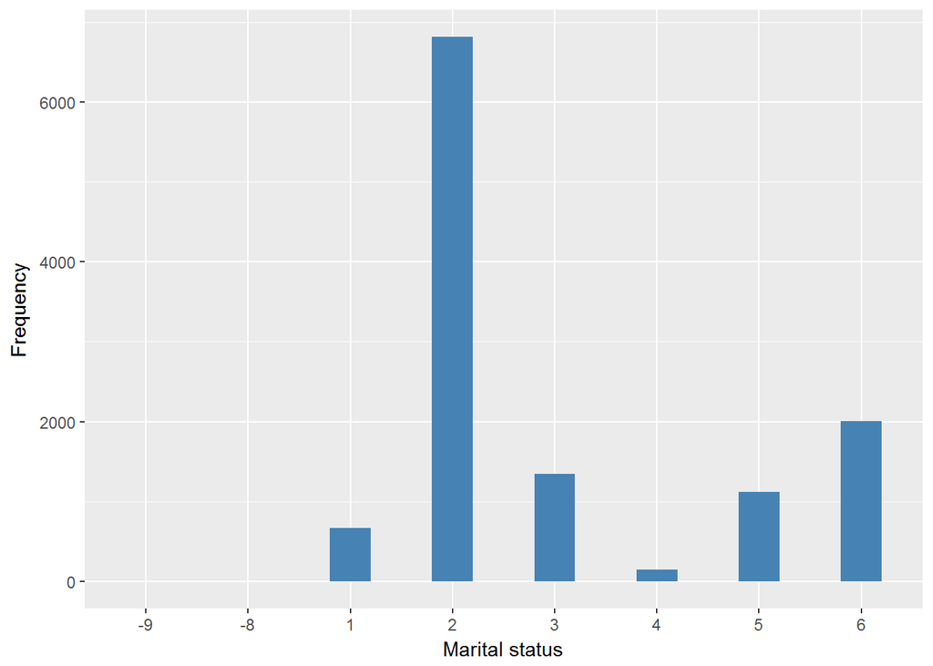

#### 2.1.1.2 Harmonisation algorithm

To compute the harmonize variable from the study-specific variable it has to be recoded as follows:

- `3,4,5 into 1`
- `1,2,6 into 0`
- `-9 into 997`
- `-8 into 998`
- `-1 into 996`
- `NA into 999`

**R script:**

```r
ELSA_ds_w1 <- tibble(id = ELSA_w1_divorce$id)
ELSA_ds_w1$divorce <- car::recode(as.vector(ELSA_w1_divorce$dimar), "1:2='0'; 6='0'; 3:5='1'; -9='997'; -8='998'; -1='996'; NA='999'")
ELSA_ds_w1$divorce <- labelled(ELSA_ds_w1$divorce, labels = c(No = 0, Yes = 1,
    Missing = 999, `Do not know` = 998, Refuse = 997, `Not applicable` = 996,
    `Don't answer` = 995, `Not attempt/not done/not yet recorded` = 994, `Disable to measure` = 993,
    Impute = 992, `CAPI/interviewer error` = 991))
```

#### 2.1.1.3 Statistical description of the new harmonised variable

| Sample size | Missing values |
| --- | --- |
| 12099 | 3 |

Category

|  | 0 | 1 |
| --- | --- | --- |
| Frequency | 9487.00 | 2609.00 |
| Percentage | 78.41 | 21.56 |

Type of missing

|  | 991 | 992 | 993 | 994 | 995 | 996 | 997 | 998 | 999 | NA |
| --- | --- | --- | --- | --- | --- | --- | --- | --- | --- | --- |
| Frequency | 0 | 0 | 0 | 0 | 0 | 0 | 2.00 | 1.00 | 0 | 0 |
| Percentage | 0 | 0 | 0 | 0 | 0 | 0 | 0.02 | 0.01 | 0 | 0 |

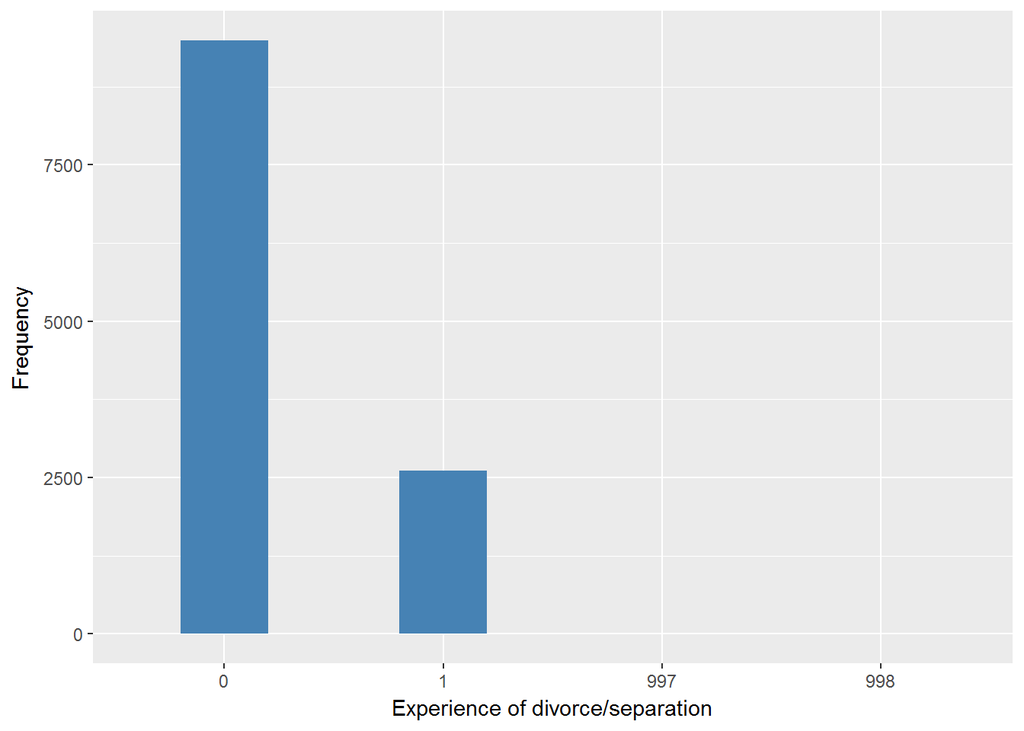

#### 2.1.1.4 Validation

|  | 1,2,6->0 | 3,4,5->1 | -9->997 | -8->998 |
| --- | --- | --- | --- | --- |
| BeforeH1 | 9487 | 2609 | 2 | 1 |
| AfterH | 9487 | 2609 | 2 | 1 |

### 2.1.2 Wave 2

#### 2.1.2.1 Study-specific variable description

The study-specific variable elected to be harmonised is:

- Name: `dimar`
- Label: `Respondent current legal marital status`
- Categories:
  - `1 = Single, that is never married`
  - `2 = Married, first and only marriage`
  - `3 = Remarried, second or later marriage`
  - `4 = Legally separated`
  - `5 = Divorced`
  - `6 = Widowed`
- Missings:
  - `-9 = Refusal`
  - `-8 = Don't Know`
  - `-1 = Not applicable`
- Name: `divorce` from the previous wave
- Description:

DIMAR

| Sample size | Missing values |
| --- | --- |
| 9432 | 1 |

Category

|  | 1 | 2 | 3 | 4 | 5 | 6 |
| --- | --- | --- | --- | --- | --- | --- |
| Frequency | 496.00 | 5233.00 | 1036.00 | 109.00 | 888.00 | 1669.0 |
| Percentage | 5.26 | 55.48 | 10.98 | 1.16 | 9.41 | 17.7 |

Type of missing

|  | -9 | -8 | -1 | NA |
| --- | --- | --- | --- | --- |
| Frequency | 0 | 1.00 | 0 | 0 |
| Percentage | 0 | 0.01 | 0 | 0 |

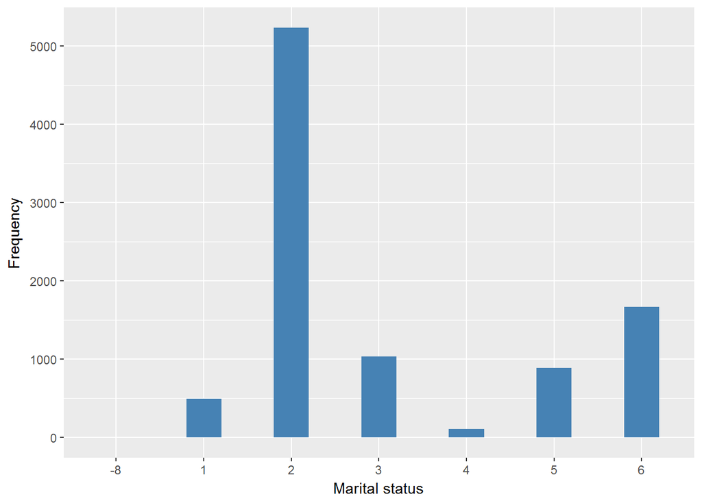

#### 2.1.2.2 Harmonisation algorithm

To compute the harmonize variable from the study-specific variable it has to be recoded as follows:

- `if divorce=1 or DiMar in 3,4,5 - into 1`
- `1,2,6 into 0`
- `-9 into 997`
- `-8 into 998`
- `-1 into 996`
- `NA into 999`

**R script:**

```r
same_indiv <- function(old, new) {

    new_2 <- matrix(NA, nrow = dim(new)[1], ncol = dim(old)[2])
    colnames(new_2) <- colnames(old)
    oldm <- as.matrix(old)

    for (i in 1:length(new$id)) {
        if (sum(new$id[i] == old$id) >= 1) {
            new_2[i, ] <- oldm[which(new$id[i] == old$id), ]
        } else {
            new_2[i, ] <- c(new$id[i], rep_len(NA, dim(old)[2] - 1))
        }
    }
    new_2 <- data.frame(new_2)
    new_22 <- data.frame(id = new_2$id, DiMar = new$DiMar, divorce = new_2$divorce)
    # id = new_2$id colname_form_OLD_table = new_2$colname_form_OLD_table
    # colname_form_NEW_table = new$colname_form_NEW_table
    new_22
}

# old = ELSA_ds_w1 (divorce) new = ELSA_w2_divorce (DiMar)

ELSA_w2_divorce_2 <- same_indiv(ELSA_ds_w1, ELSA_w2_divorce)

ELSA_ds_w2 <- tibble(id = ELSA_w2_divorce_2$id)

ELSA_w2_divorce_2$divorce <- car::recode(as.vector(ELSA_w2_divorce_2$divorce),
    "NA='-999'")
ELSA_w2_divorce_2$DiMar <- car::recode(as.vector(ELSA_w2_divorce_2$DiMar), "NA='-999'")

ELSA_ds_w2$divorce <- c(NA)
for (i in 1:dim(ELSA_w2_divorce_2[1])) {
    if (ELSA_w2_divorce_2$divorce[i] == 1 | ELSA_w2_divorce_2$DiMar[i] %in%
        c(3, 4, 5)) {
        ELSA_ds_w2$divorce[i] = 1
    } else if (ELSA_w2_divorce_2$DiMar[i] %in% c(1, 2, 6)) {
        ELSA_ds_w2$divorce[i] = 0
    } else if (ELSA_w2_divorce_2$DiMar[i] == -9) {
        ELSA_ds_w2$divorce[i] = 997
    } else if (ELSA_w2_divorce_2$DiMar[i] == -8) {
        ELSA_ds_w2$divorce[i] = 998
    } else if (ELSA_w2_divorce_2$DiMar[i] == -1) {
        ELSA_ds_w2$divorce[i] = 996
    }
}

ELSA_ds_w2$divorce <- car::recode(as.vector(ELSA_ds_w2$divorce), "NA='999'")
ELSA_ds_w2$divorce <- labelled(ELSA_ds_w2$divorce, labels = c(No = 0, Yes = 1,
    Missing = 999, `Do not know` = 998, Refuse = 997, `Not applicable` = 996,
    `Don't answer` = 995, `Not attempt/not done/not yet recorded` = 994, `Disable to measure` = 993,
    Impute = 992, `CAPI/interviewer error` = 991))
```

#### 2.1.2.3 Statistical description of the new harmonised variable

| Sample size | Missing values |
| --- | --- |
| 9432 | 1 |

Category

|  | 0 | 1 |
| --- | --- | --- |
| Frequency | 7186.00 | 2245.0 |
| Percentage | 76.19 | 23.8 |

Type of missing

|  | 991 | 992 | 993 | 994 | 995 | 996 | 997 | 998 | 999 | NA |
| --- | --- | --- | --- | --- | --- | --- | --- | --- | --- | --- |
| Frequency | 0 | 0 | 0 | 0 | 0 | 0 | 0 | 1.00 | 0 | 0 |
| Percentage | 0 | 0 | 0 | 0 | 0 | 0 | 0 | 0.01 | 0 | 0 |

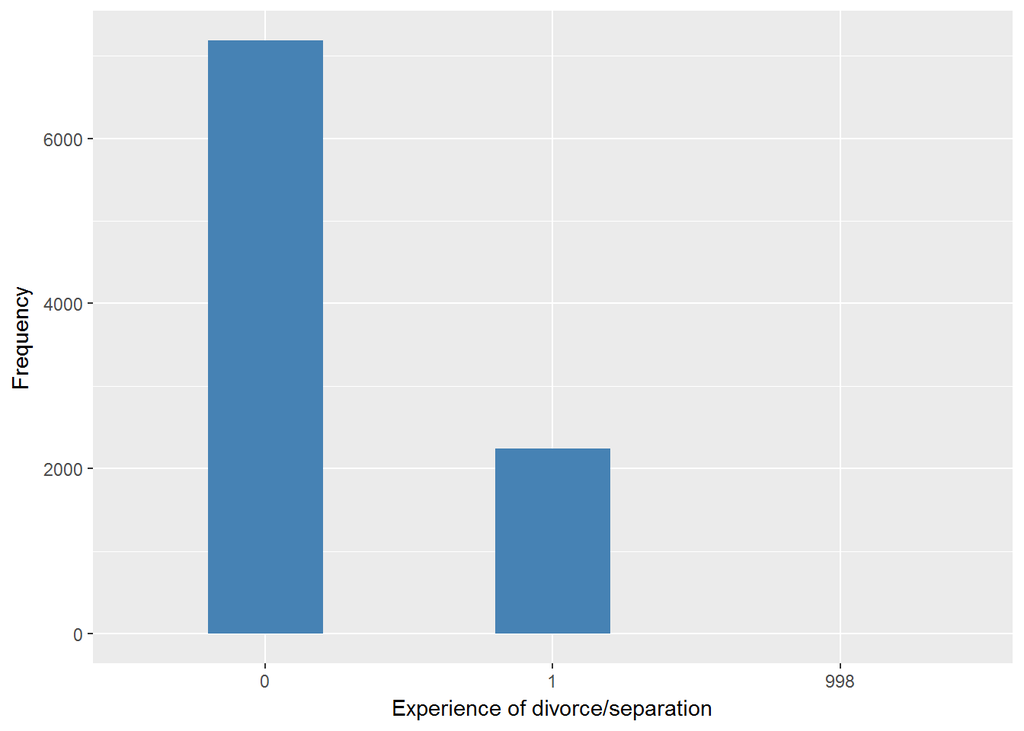

#### 2.1.2.4 Validation

### 2.1.3 Wave 3

#### 2.1.3.1 Study-specific variable description

The study-specific variable elected to be harmonised is:

- Name: `dimar`
- Label: `Respondent current legal marital status`
- Categories:
  - `1 = Single, that is never married`
  - `2 = Married, first and only marriage`
  - `3 = A civil partner in a legally-recognised Civil Partnership`
  - `4 = Remarried, second or later marriage`
  - `5 = Legally separated`
  - `6 = Divorced`
  - `7 = Widowed`
  - `8 = In legally-recognised Civil Partnership and separated from his/her civil partner`
  - `9 = Formerly a civil partner, the Civil Partnership is now legally dissolved`
  - `10 = A surviving civil partner: his/her partner having since died`
  - `11 = A civil partner and has been married or in another Civil Partnership before`
- Missings:
  - `-9 = Refusal`
  - `-8 = Don't Know`
  - `-2 = Schedule not applicable`
  - `-1 = Not applicable`
- Name: `divorce` from the previous wave
- Description:

DIMAR

| Sample size | Missing values |
| --- | --- |
| 9771 | 1 |

Category

|  | 1 | 2 | 3 | 4 | 5 | 6 | 7 | 8 | 11 |
| --- | --- | --- | --- | --- | --- | --- | --- | --- | --- |
| Frequency | 574.00 | 5345.0 | 9.00 | 1182.0 | 94.00 | 989.00 | 1572.00 | 3.00 | 2.00 |
| Percentage | 5.87 | 54.7 | 0.09 | 12.1 | 0.96 | 10.12 | 16.09 | 0.03 | 0.02 |

Type of missing

|  | -9 | -8 | -2 | -1 | NA |
| --- | --- | --- | --- | --- | --- |
| Frequency | 0 | 1.00 | 0 | 0 | 0 |
| Percentage | 0 | 0.01 | 0 | 0 | 0 |

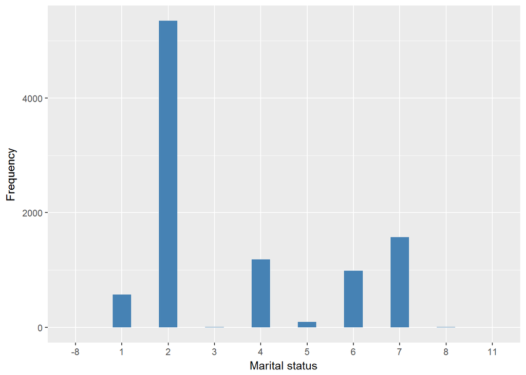

#### 2.1.3.2 Harmonisation algorithm

To recode the harmonize variable from the study-specific variable it has to be recoded as follows:

- `if divorce=1 OR dimar in 4,5,6,8,9 -> into 1`
- `1,2,3,7,10,11 -> into 0`
- `-9 into 997`
- `-8 into 998`
- `-2 into 996`
- `-1 into 996`
- `NA into 999`

**R script:**

```r
same_indiv <- function(old, new) {

    new_2 <- matrix(NA, nrow = dim(new)[1], ncol = dim(old)[2])
    colnames(new_2) <- colnames(old)
    oldm <- as.matrix(old)

    for (i in 1:length(new$id)) {
        if (sum(new$id[i] == old$id) >= 1) {
            new_2[i, ] <- oldm[which(new$id[i] == old$id), ]
        } else {
            new_2[i, ] <- c(new$id[i], rep_len(NA, dim(old)[2] - 1))
        }
    }
    new_2 <- data.frame(new_2)
    new_22 <- data.frame(id = new_2$id, dimar = new$dimar, divorce = new_2$divorce)
    # id = new_2$id colname_form_OLD_table = new_2$colname_form_OLD_table
    # colname_form_NEW_table = new$colname_form_NEW_table
    new_22
}

# old = ELSA_ds_w2 (divorce) new = ELSA_w3_divorce (dimar)

ELSA_w3_divorce_2 <- same_indiv(ELSA_ds_w2, ELSA_w3_divorce)

ELSA_ds_w3 <- tibble(id = ELSA_w3_divorce_2$id)

ELSA_w3_divorce_2$divorce <- car::recode(as.vector(ELSA_w3_divorce_2$divorce),
    "NA='-999'")
ELSA_w3_divorce_2$dimar <- car::recode(as.vector(ELSA_w3_divorce_2$dimar), "NA='-999'")

ELSA_ds_w3$divorce <- c(NA)
for (i in 1:dim(ELSA_w3_divorce_2[1])) {
    if (ELSA_w3_divorce_2$divorce[i] == 1 | ELSA_w3_divorce_2$dimar[i] %in%
        c(4, 5, 6, 8, 9)) {
        ELSA_ds_w3$divorce[i] = 1
    } else if (ELSA_w3_divorce_2$dimar[i] %in% c(1, 2, 3, 7, 10, 11)) {
        ELSA_ds_w3$divorce[i] = 0
    } else if (ELSA_w3_divorce_2$dimar[i] == -9) {
        ELSA_ds_w3$divorce[i] = 997
    } else if (ELSA_w3_divorce_2$dimar[i] == -8) {
        ELSA_ds_w3$divorce[i] = 998
    } else if (ELSA_w3_divorce_2$dimar[i] == -2) {
        ELSA_ds_w3$divorce[i] = 996
    } else if (ELSA_w3_divorce_2$dimar[i] == -1) {
        ELSA_ds_w3$divorce[i] = 996
    }
}

ELSA_ds_w3$divorce <- car::recode(as.vector(ELSA_ds_w3$divorce), "NA='999'")
ELSA_ds_w3$divorce <- labelled(ELSA_ds_w3$divorce, labels = c(No = 0, Yes = 1,
    Missing = 999, `Do not know` = 998, Refuse = 997, `Not applicable` = 996,
    `Don't answer` = 995, `Not attempt/not done/not yet recorded` = 994, `Disable to measure` = 993,
    Impute = 992, `CAPI/interviewer error` = 991))
```

#### 2.1.3.3 Statistical description of the new harmonised variable

| Sample size | Missing values |
| --- | --- |
| 9771 | 1 |

Category

|  | 0 | 1 |
| --- | --- | --- |
| Frequency | 7289.0 | 2481.00 |
| Percentage | 74.6 | 25.39 |

Type of missing

|  | 991 | 992 | 993 | 994 | 995 | 996 | 997 | 998 | 999 | NA |
| --- | --- | --- | --- | --- | --- | --- | --- | --- | --- | --- |
| Frequency | 0 | 0 | 0 | 0 | 0 | 0 | 0 | 1.00 | 0 | 0 |
| Percentage | 0 | 0 | 0 | 0 | 0 | 0 | 0 | 0.01 | 0 | 0 |

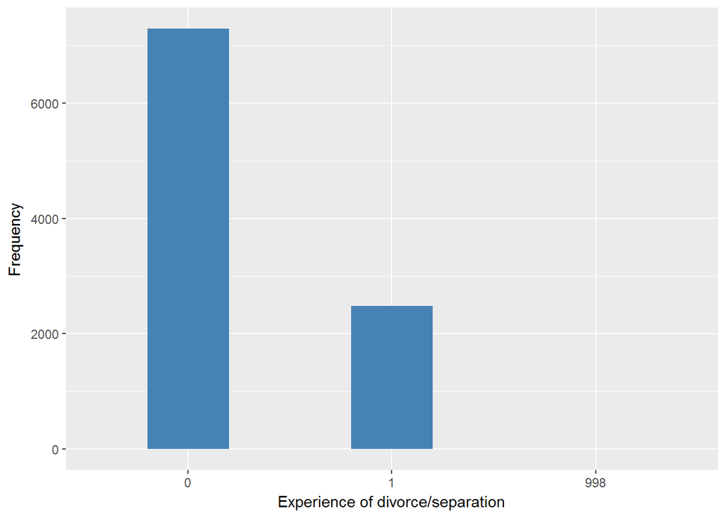

##### 2.1.3.3.1 Validation

### 2.1.4 Wave 4

#### 2.1.4.1 Study-specific variable description

The study-specific variable elected to be harmonised is:

- Name: `dimar`
- Label: `Respondent current legal marital status`
- Categories:
  - `1 = Single, that is never married`
  - `2 = Married, first and only marriage`
  - `3 = A civil partner in a legally-recognised Civil Partnership`
  - `4 = Remarried, second or later marriage`
  - `5 = Legally separated`
  - `6 = Divorced`
  - `7 = Widowed`
  - `8 = In legally-recognised Civil Partnership and separated from his/her civil partner`
  - `9 = Formerly a civil partner, the Civil Partnership is now legally dissolved`
  - `10 = [Spontaneous only] A surviving civil partner: his/her partner having since died`
  - `11 = A civil partner and has been married or in another Civil Partnership before`
- Missings:
  - `-9 = Refusal`
  - `-8 = Don't Know`
  - `-2 = Schedule not applicable`
  - `-1 = Item not applicable`
- Name: `divorce` from the previous wave
- Description:

DIMAR

| Sample size | Missing values |
| --- | --- |
| 11050 | 2 |

Category

|  | 1 | 2 | 3 | 4 | 5 | 6 | 7 | 8 | 11 |
| --- | --- | --- | --- | --- | --- | --- | --- | --- | --- |
| Frequency | 675.00 | 6077 | 32.00 | 1396.00 | 93.00 | 1138.0 | 1632.00 | 2.00 | 3.00 |
| Percentage | 6.11 | 55 | 0.29 | 12.63 | 0.84 | 10.3 | 14.77 | 0.02 | 0.03 |

Type of missing

|  | -9 | -8 | -2 | -1 | NA |
| --- | --- | --- | --- | --- | --- |
| Frequency | 2.00 | 0 | 0 | 0 | 0 |
| Percentage | 0.02 | 0 | 0 | 0 | 0 |

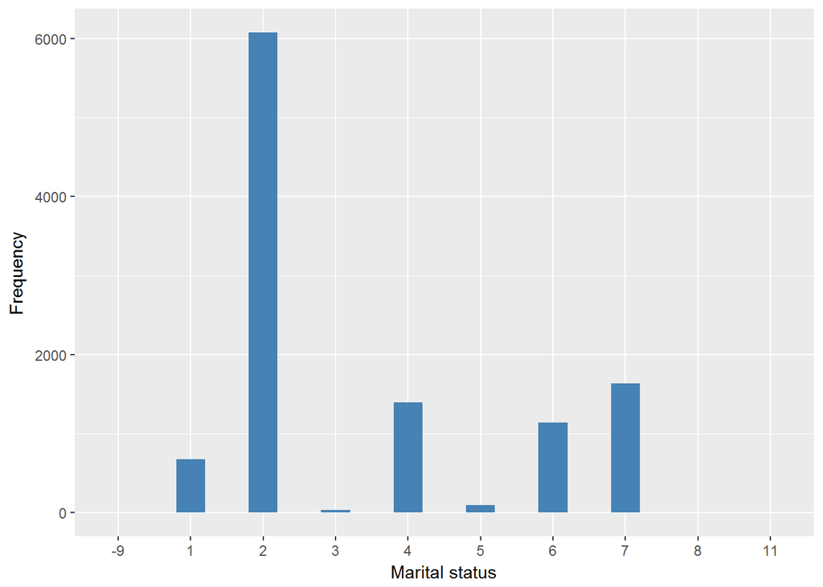

#### 2.1.4.2 Harmonisation algorithm

To recode the harmonize variable from the study-specific variable it has to be recoded as follows:

- `4,5,6,8,9 into 1`
- `1,2,3,7,10,11 into 0`
- `-9 into 997`
- `-8 into 998`
- `-2 into 996`
- `-1 into 996`
- `NA into 999`

**R script:**

```r
same_indiv <- function(old, new) {

    new_2 <- matrix(NA, nrow = dim(new)[1], ncol = dim(old)[2])
    colnames(new_2) <- colnames(old)
    oldm <- as.matrix(old)

    for (i in 1:length(new$id)) {
        if (sum(new$id[i] == old$id) >= 1) {
            new_2[i, ] <- oldm[which(new$id[i] == old$id), ]
        } else {
            new_2[i, ] <- c(new$id[i], rep_len(NA, dim(old)[2] - 1))
        }
    }
    new_2 <- data.frame(new_2)
    new_22 <- data.frame(id = new_2$id, dimar = new$dimar, divorce = new_2$divorce)
    # id = new_2$id colname_form_OLD_table = new_2$colname_form_OLD_table
    # colname_form_NEW_table = new$colname_form_NEW_table
    new_22
}

# old = ELSA_ds_w3 (divorce) new = ELSA_w4_divorce (dimar)

ELSA_w4_divorce_2 <- same_indiv(ELSA_ds_w3, ELSA_w4_divorce)

ELSA_ds_w4 <- tibble(id = ELSA_w4_divorce_2$id)

ELSA_w4_divorce_2$divorce <- car::recode(as.vector(ELSA_w4_divorce_2$divorce),
    "NA='-999'")
ELSA_w4_divorce_2$dimar <- car::recode(as.vector(ELSA_w4_divorce_2$dimar), "NA='-999'")

ELSA_ds_w4$divorce <- c(NA)
for (i in 1:dim(ELSA_w4_divorce_2[1])) {
    if (ELSA_w4_divorce_2$divorce[i] == 1 | ELSA_w4_divorce_2$dimar[i] %in%
        c(4, 5, 6, 8, 9)) {
        ELSA_ds_w4$divorce[i] = 1
    } else if (ELSA_w4_divorce_2$dimar[i] %in% c(1, 2, 3, 7, 10, 11)) {
        ELSA_ds_w4$divorce[i] = 0
    } else if (ELSA_w4_divorce_2$dimar[i] == -9) {
        ELSA_ds_w4$divorce[i] = 997
    } else if (ELSA_w4_divorce_2$dimar[i] == -8) {
        ELSA_ds_w4$divorce[i] = 998
    } else if (ELSA_w4_divorce_2$dimar[i] == -2) {
        ELSA_ds_w4$divorce[i] = 996
    } else if (ELSA_w4_divorce_2$dimar[i] == -1) {
        ELSA_ds_w4$divorce[i] = 996
    }
}

ELSA_ds_w4$divorce <- car::recode(as.vector(ELSA_ds_w4$divorce), "NA='999'")
ELSA_ds_w4$divorce <- labelled(ELSA_ds_w4$divorce, labels = c(No = 0, Yes = 1,
    Missing = 999, `Do not know` = 998, Refuse = 997, `Not applicable` = 996,
    `Don't answer` = 995, `Not attempt/not done/not yet recorded` = 994, `Disable to measure` = 993,
    Impute = 992, `CAPI/interviewer error` = 991))
```

#### 2.1.4.3 Statistical description of the new harmonised variable

| Sample size | Missing values |
| --- | --- |
| 11050 | 2 |

Category

|  | 0 | 1 |
| --- | --- | --- |
| Frequency | 8152.00 | 2896.00 |
| Percentage | 73.77 | 26.21 |

Type of missing

|  | 991 | 992 | 993 | 994 | 995 | 996 | 997 | 998 | 999 | NA |
| --- | --- | --- | --- | --- | --- | --- | --- | --- | --- | --- |
| Frequency | 0 | 0 | 0 | 0 | 0 | 0 | 2.00 | 0 | 0 | 0 |
| Percentage | 0 | 0 | 0 | 0 | 0 | 0 | 0.02 | 0 | 0 | 0 |

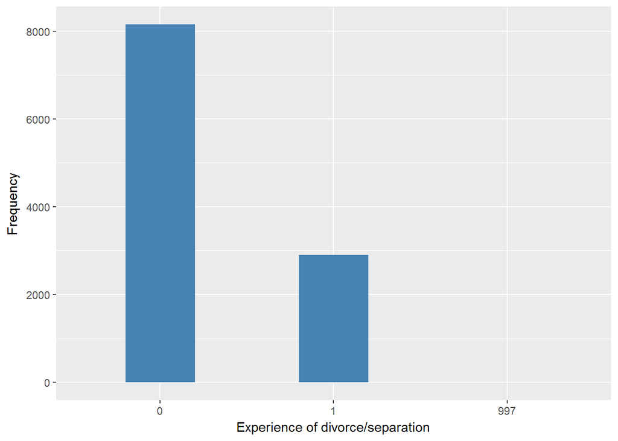

##### 2.1.4.3.1 Validation

### 2.1.5 Wave 5

#### 2.1.5.1 Study-specific variable description

The study-specific variable elected to be harmonised is:

- Name: `dimar`
- Label: `Respondent current legal marital status`
- Categories:
  - `1 = Single, that is never married`
  - `2 = Married, first and only marriage`
  - `3 = A civil partner in a legally-recognised Civil Partnership`
  - `4 = Remarried, second or later marriage`
  - `5 = Legally separated`
  - `6 = Divorced`
  - `7 = Widowed`
  - `8 = [Spontaneous only] In legally-recognised Civil Partnership and separated from his/her civil partner`
  - `9 = [Spontaneous only] Formerly a civil partner, the Civil Partnership is now legally dissolved`
  - `10 = [Spontaneous only] A surviving civil partner: his/her partner having since died`
  - `11 = [Spontaneous only] A civil partner and has been married or in another Civil Partnership before`
- Missings:
  - `-9 = Refusal`
  - `-8 = Don't Know`
  - `-2 = Schedule not applicable`
  - `-1 = Item not applicable`
- Name: `divorce` from the previous wave
- Description:

DIMAR

| Sample size | Missing values |
| --- | --- |
| 10274 | 6 |

Category

|  | 1 | 2 | 3 | 4 | 5 | 6 | 7 | 8 |
| --- | --- | --- | --- | --- | --- | --- | --- | --- |
| Frequency | 596.0 | 5704.00 | 32.00 | 1191.00 | 77.00 | 1081.00 | 1586.00 | 1.00 |
| Percentage | 5.8 | 55.52 | 0.31 | 11.59 | 0.75 | 10.52 | 15.44 | 0.01 |

Type of missing

|  | -9 | -8 | -2 | -1 | NA |
| --- | --- | --- | --- | --- | --- |
| Frequency | 3.00 | 3.00 | 0 | 0 | 0 |
| Percentage | 0.03 | 0.03 | 0 | 0 | 0 |

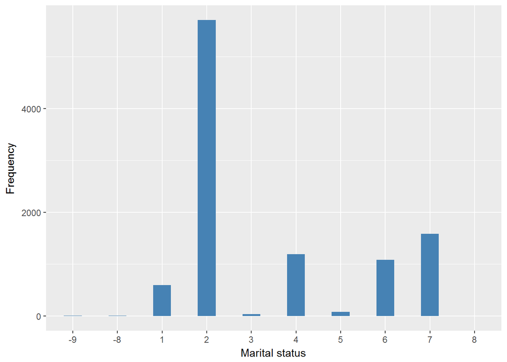

#### 2.1.5.2 Harmonisation algorithm

To recode the harmonize variable from the study-specific variable it has to be recoded as follows:

- `4,5,6,8,9 into 1`
- `1,2,3,7,10,11 into 0`
- `-9 into 997`
- `-8 into 998`
- `-2 into 996`
- `-1 into 996`
- `NA into 999`

**R script:**

```r
same_indiv <- function(old, new) {

    new_2 <- matrix(NA, nrow = dim(new)[1], ncol = dim(old)[2])
    colnames(new_2) <- colnames(old)
    oldm <- as.matrix(old)

    for (i in 1:length(new$id)) {
        if (sum(new$id[i] == old$id) >= 1) {
            new_2[i, ] <- oldm[which(new$id[i] == old$id), ]
        } else {
            new_2[i, ] <- c(new$id[i], rep_len(NA, dim(old)[2] - 1))
        }
    }
    new_2 <- data.frame(new_2)
    new_22 <- data.frame(id = new_2$id, dimar = new$dimar, divorce = new_2$divorce)
    # id = new_2$id colname_form_OLD_table = new_2$colname_form_OLD_table
    # colname_form_NEW_table = new$colname_form_NEW_table
    new_22
}

# old = ELSA_ds_w4 (divorce) new = ELSA_w5_divorce (dimar)

ELSA_w5_divorce_2 <- same_indiv(ELSA_ds_w4, ELSA_w5_divorce)

ELSA_ds_w5 <- tibble(id = ELSA_w5_divorce_2$id)

ELSA_w5_divorce_2$divorce <- car::recode(as.vector(ELSA_w5_divorce_2$divorce),
    "NA='-999'")
ELSA_w5_divorce_2$dimar <- car::recode(as.vector(ELSA_w5_divorce_2$dimar), "NA='-999'")

ELSA_ds_w5$divorce <- c(NA)
for (i in 1:dim(ELSA_w5_divorce_2[1])) {
    if (ELSA_w5_divorce_2$divorce[i] == 1 | ELSA_w5_divorce_2$dimar[i] %in%
        c(4, 5, 6, 8, 9)) {
        ELSA_ds_w5$divorce[i] = 1
    } else if (ELSA_w5_divorce_2$dimar[i] %in% c(1, 2, 3, 7, 10, 11)) {
        ELSA_ds_w5$divorce[i] = 0
    } else if (ELSA_w5_divorce_2$dimar[i] == -9) {
        ELSA_ds_w5$divorce[i] = 997
    } else if (ELSA_w5_divorce_2$dimar[i] == -8) {
        ELSA_ds_w5$divorce[i] = 998
    } else if (ELSA_w5_divorce_2$dimar[i] == -2) {
        ELSA_ds_w5$divorce[i] = 996
    } else if (ELSA_w5_divorce_2$dimar[i] == -1) {
        ELSA_ds_w5$divorce[i] = 996
    }
}

ELSA_ds_w5$divorce <- car::recode(as.vector(ELSA_ds_w5$divorce), "NA='999'")
ELSA_ds_w5$divorce <- labelled(ELSA_ds_w5$divorce, labels = c(No = 0, Yes = 1,
    Missing = 999, `Do not know` = 998, Refuse = 997, `Not applicable` = 996,
    `Don't answer` = 995, `Not attempt/not done/not yet recorded` = 994, `Disable to measure` = 993,
    Impute = 992, `CAPI/interviewer error` = 991))
```

#### 2.1.5.3 Statistical description of the new harmonised variable

| Sample size | Missing values |
| --- | --- |
| 10274 | 5 |

Category

|  | 0 | 1 |
| --- | --- | --- |
| Frequency | 7508.00 | 2761.00 |
| Percentage | 73.08 | 26.87 |

Type of missing

|  | 991 | 992 | 993 | 994 | 995 | 996 | 997 | 998 | 999 | NA |
| --- | --- | --- | --- | --- | --- | --- | --- | --- | --- | --- |
| Frequency | 0 | 0 | 0 | 0 | 0 | 0 | 3.00 | 2.00 | 0 | 0 |
| Percentage | 0 | 0 | 0 | 0 | 0 | 0 | 0.03 | 0.02 | 0 | 0 |

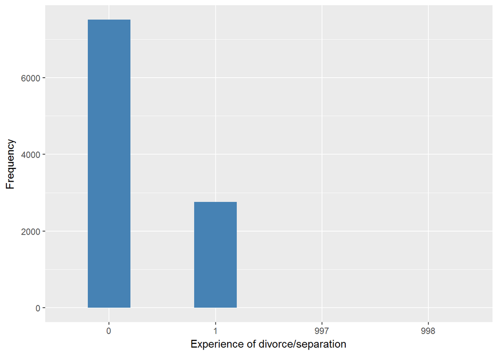

##### 2.1.5.3.1 Validation

### 2.1.6 Wave 6

#### 2.1.6.1 Study-specific variable description

The study-specific variable elected to be harmonised is:

- Name: `DiMar`
- Label: `Respondent current legal marital status`
- Categories:
  - `1 = Single, that is never married`
  - `2 = Married, first and only marriage`
  - `3 = A civil partner in a legally-recognised Civil Partnership`
  - `4 = Remarried, second or later marriage`
  - `5 = Legally separated`
  - `6 = Divorced`
  - `7 = Widowed`
  - `8 = [Spontaneous only] In legally-recognised Civil Partnership and separated from his/her civil partner`
  - `9 = [Spontaneous only] Formerly a civil partner, the Civil Partnership is now legally dissolved`
  - `10 = [Spontaneous only] A surviving civil partner: his/her partner having since died`
  - `11 = [Spontaneous only] A civil partner and has been married or in another Civil Partnership before`
- Missings:
  - `-9 = Refusal`
  - `-8 = Don't Know`
  - `-2 = Schedule not applicable`
  - `-1 = Item not applicable`
- Name: `divorce` from the previous wave
- Description:

DIMAR

| Sample size | Missing values |
| --- | --- |
| 10601 | 3 |

Category

|  | 1 | 2 | 3 | 4 | 5 | 6 | 7 | 8 |
| --- | --- | --- | --- | --- | --- | --- | --- | --- |
| Frequency | 670.00 | 5862.0 | 32.0 | 1241.00 | 96.00 | 1146.00 | 1548.0 | 3.00 |
| Percentage | 6.32 | 55.3 | 0.3 | 11.71 | 0.91 | 10.81 | 14.6 | 0.03 |

Type of missing

|  | -9 | -8 | -2 | -1 | NA |
| --- | --- | --- | --- | --- | --- |
| Frequency | 1.00 | 2.00 | 0 | 0 | 0 |
| Percentage | 0.01 | 0.02 | 0 | 0 | 0 |

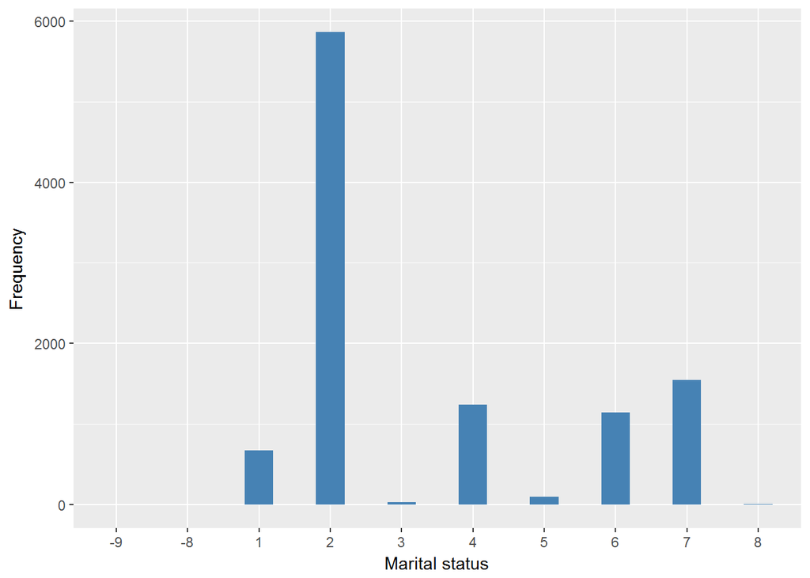

#### 2.1.6.2 Harmonisation algorithm

To recode the harmonize variable from the study-specific variable it has to be recoded as follows:

- `4,5,6,8,9 into 1`
- `1,2,3,7,10,11 into 0`
- `-9 into 997`
- `-8 into 998`
- `-2 into 996`
- `-1 into 996`
- `NA into 999`

**R script:**

```r
same_indiv <- function(old, new) {

    new_2 <- matrix(NA, nrow = dim(new)[1], ncol = dim(old)[2])
    colnames(new_2) <- colnames(old)
    oldm <- as.matrix(old)

    for (i in 1:length(new$id)) {
        if (sum(new$id[i] == old$id) >= 1) {
            new_2[i, ] <- oldm[which(new$id[i] == old$id), ]
        } else {
            new_2[i, ] <- c(new$id[i], rep_len(NA, dim(old)[2] - 1))
        }
    }
    new_2 <- data.frame(new_2)
    new_22 <- data.frame(id = new_2$id, DiMar = new$DiMar, divorce = new_2$divorce)
    # id = new_2$id colname_form_OLD_table = new_2$colname_form_OLD_table
    # colname_form_NEW_table = new$colname_form_NEW_table
    new_22
}

# old = ELSA_ds_w5 (divorce) new = ELSA_w6_divorce (DiMar)

ELSA_w6_divorce_2 <- same_indiv(ELSA_ds_w5, ELSA_w6_divorce)

ELSA_ds_w6 <- tibble(id = ELSA_w6_divorce_2$id)

ELSA_w6_divorce_2$divorce <- car::recode(as.vector(ELSA_w6_divorce_2$divorce),
    "NA='-999'")
ELSA_w6_divorce_2$DiMar <- car::recode(as.vector(ELSA_w6_divorce_2$DiMar), "NA='-999'")

ELSA_ds_w6$divorce <- c(NA)
for (i in 1:dim(ELSA_w6_divorce_2[1])) {
    if (ELSA_w6_divorce_2$divorce[i] == 1 | ELSA_w6_divorce_2$DiMar[i] %in%
        c(4, 5, 6, 8, 9)) {
        ELSA_ds_w6$divorce[i] = 1
    } else if (ELSA_w6_divorce_2$DiMar[i] %in% c(1, 2, 3, 7, 10, 11)) {
        ELSA_ds_w6$divorce[i] = 0
    } else if (ELSA_w6_divorce_2$DiMar[i] == -9) {
        ELSA_ds_w6$divorce[i] = 997
    } else if (ELSA_w6_divorce_2$DiMar[i] == -8) {
        ELSA_ds_w6$divorce[i] = 998
    } else if (ELSA_w6_divorce_2$DiMar[i] == -2) {
        ELSA_ds_w6$divorce[i] = 996
    } else if (ELSA_w6_divorce_2$DiMar[i] == -1) {
        ELSA_ds_w6$divorce[i] = 996
    }
}

ELSA_ds_w6$divorce <- car::recode(as.vector(ELSA_ds_w6$divorce), "NA='999'")
ELSA_ds_w6$divorce <- labelled(ELSA_ds_w6$divorce, labels = c(No = 0, Yes = 1,
    Missing = 999, `Do not know` = 998, Refuse = 997, `Not applicable` = 996,
    `Don't answer` = 995, `Not attempt/not done/not yet recorded` = 994, `Disable to measure` = 993,
    Impute = 992, `CAPI/interviewer error` = 991))
```

#### 2.1.6.3 Statistical description of the new harmonised variable

| Sample size | Missing values |
| --- | --- |
| 10601 | 1 |

Category

|  | 0 | 1 |
| --- | --- | --- |
| Frequency | 7631.00 | 2969.00 |
| Percentage | 71.98 | 28.01 |

Type of missing

|  | 991 | 992 | 993 | 994 | 995 | 996 | 997 | 998 | 999 | NA |
| --- | --- | --- | --- | --- | --- | --- | --- | --- | --- | --- |
| Frequency | 0 | 0 | 0 | 0 | 0 | 0 | 0 | 1.00 | 0 | 0 |
| Percentage | 0 | 0 | 0 | 0 | 0 | 0 | 0 | 0.01 | 0 | 0 |

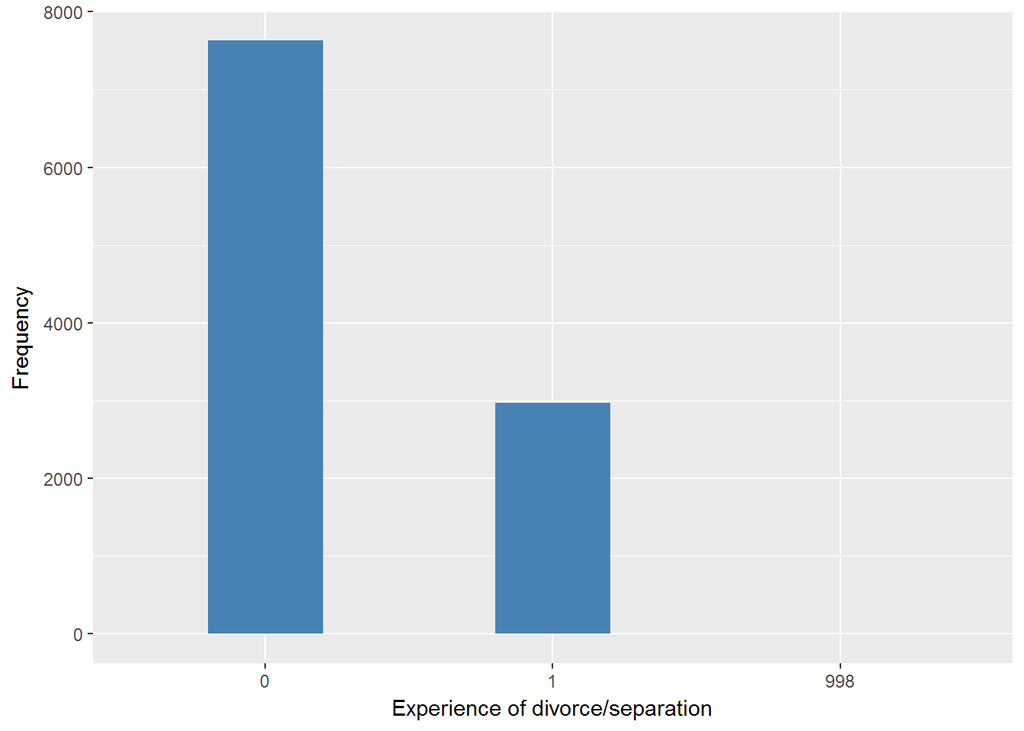

#### 2.1.6.4 Validation

### 2.1.7 Wave 7

#### 2.1.7.1 Study-specific variable description

The study-specific variable elected to be harmonised is:

- Name: `DiMar`
- Label: `Respondent current legal marital status`
- Categories:
  - `1 = Single, that is never married and never registered in a same`
  - `2 = Married, first and only marriage`
  - `3 = A civil partner in a registered same-sex Civil Partnership`
  - `4 = Remarried, second or later marriage`
  - `5 = Separated, but still legally married`
  - `6 = Divorced`
  - `7 = Widowed`
  - `8 = Spontaneous only - Separated but still legally in a same-sex`
  - `9 = Spontaneous only - Formerly in a same-sex Civil Partnership`
  - `10 = Spontaneous only - A surviving civil partner from a same-sex`
  - `11 = Spontaneous only - A civil partner in a registered same-sex`
- Missings:
  - `-9 = Refusal`
  - `-8 = Don't Know`
  - `-2 = Schedule not applicable`
  - `-1 = Item not applicable`
- Name: `divorce` from the previous wave
- Description:

| Sample size | Missing values |
| --- | --- |
| 9666 | 2 |

Category

|  | 1 | 2 | 3 | 4 | 5 | 6 | 7 | 8 | 9 | 11 |
| --- | --- | --- | --- | --- | --- | --- | --- | --- | --- | --- |
| Frequency | 624.00 | 5362.00 | 33.00 | 1033.00 | 124.00 | 1079.00 | 1405.00 | 1.00 | 1.00 | 2.00 |
| Percentage | 6.46 | 55.47 | 0.34 | 10.69 | 1.28 | 11.16 | 14.54 | 0.01 | 0.01 | 0.02 |

Type of missing

|  | -9 | -8 | -2 | -1 | NA |
| --- | --- | --- | --- | --- | --- |
| Frequency | 2.00 | 0 | 0 | 0 | 0 |
| Percentage | 0.02 | 0 | 0 | 0 | 0 |

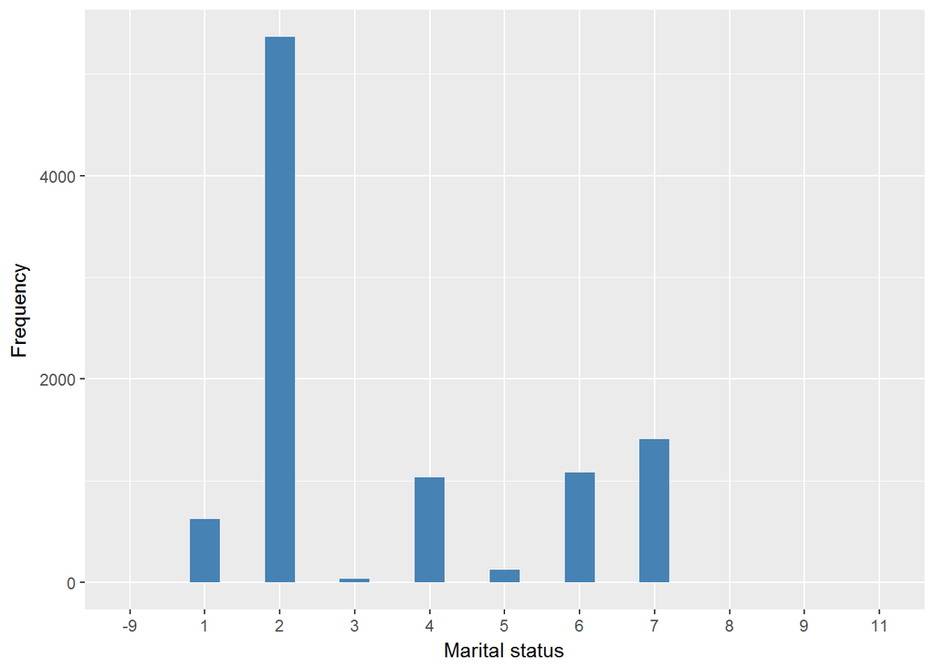

#### 2.1.7.2 Harmonisation algorithm

To recode the harmonize variable from the study-specific variable it has to be recoded as follows:

- `4,5,6,8 into 1`
- `1,2,3,7,9,10,11 into 0`
- `-9 into 997`
- `-8 into 998`
- `-2 into 996`
- `-1 into 996`
- `NA into 999`

**R script:**

```r
same_indiv <- function(old, new) {

    new_2 <- matrix(NA, nrow = dim(new)[1], ncol = dim(old)[2])
    colnames(new_2) <- colnames(old)
    oldm <- as.matrix(old)

    for (i in 1:length(new$id)) {
        if (sum(new$id[i] == old$id) >= 1) {
            new_2[i, ] <- oldm[which(new$id[i] == old$id), ]
        } else {
            new_2[i, ] <- c(new$id[i], rep_len(NA, dim(old)[2] - 1))
        }
    }
    new_2 <- data.frame(new_2)
    new_22 <- data.frame(id = new_2$id, DiMar = new$DiMar, divorce = new_2$divorce)
    # id = new_2$id colname_form_OLD_table = new_2$colname_form_OLD_table
    # colname_form_NEW_table = new$colname_form_NEW_table
    new_22
}

# old = ELSA_ds_w6 (divorce) new = ELSA_w7_divorce (DiMar)

ELSA_w7_divorce_2 <- same_indiv(ELSA_ds_w6, ELSA_w7_divorce)

ELSA_ds_w7 <- tibble(id = ELSA_w7_divorce_2$id)

ELSA_w7_divorce_2$divorce <- car::recode(as.vector(ELSA_w7_divorce_2$divorce),
    "NA='-999'")
ELSA_w7_divorce_2$DiMar <- car::recode(as.vector(ELSA_w7_divorce_2$DiMar), "NA='-999'")

ELSA_ds_w7$divorce <- c(NA)
for (i in 1:dim(ELSA_w7_divorce_2[1])) {
    if (ELSA_w7_divorce_2$divorce[i] == 1 | ELSA_w7_divorce_2$DiMar[i] %in%
        c(4, 5, 6, 8)) {
        ELSA_ds_w7$divorce[i] = 1
    } else if (ELSA_w7_divorce_2$DiMar[i] %in% c(1, 2, 3, 7, 9, 10, 11)) {
        ELSA_ds_w7$divorce[i] = 0
    } else if (ELSA_w7_divorce_2$DiMar[i] == -9) {
        ELSA_ds_w7$divorce[i] = 997
    } else if (ELSA_w7_divorce_2$DiMar[i] == -8) {
        ELSA_ds_w7$divorce[i] = 998
    } else if (ELSA_w7_divorce_2$DiMar[i] == -2) {
        ELSA_ds_w7$divorce[i] = 996
    } else if (ELSA_w7_divorce_2$DiMar[i] == -1) {
        ELSA_ds_w7$divorce[i] = 996
    }
}

ELSA_ds_w7$divorce <- car::recode(as.vector(ELSA_ds_w7$divorce), "NA='999'")
ELSA_ds_w7$divorce <- labelled(ELSA_ds_w7$divorce, labels = c(No = 0, Yes = 1,
    Missing = 999, `Do not know` = 998, Refuse = 997, `Not applicable` = 996,
    `Don't answer` = 995, `Not attempt/not done/not yet recorded` = 994, `Disable to measure` = 993,
    Impute = 992, `CAPI/interviewer error` = 991))
```

#### 2.1.7.3 Statistical description of the new harmonised variable

| Sample size | Missing values |
| --- | --- |
| 9666 | 1 |

Category

|  | 0 | 1 |
| --- | --- | --- |
| Frequency | 6880.00 | 2785.00 |
| Percentage | 71.18 | 28.81 |

Type of missing

|  | 991 | 992 | 993 | 994 | 995 | 996 | 997 | 998 | 999 | NA |
| --- | --- | --- | --- | --- | --- | --- | --- | --- | --- | --- |
| Frequency | 0 | 0 | 0 | 0 | 0 | 0 | 1.00 | 0 | 0 | 0 |
| Percentage | 0 | 0 | 0 | 0 | 0 | 0 | 0.01 | 0 | 0 | 0 |

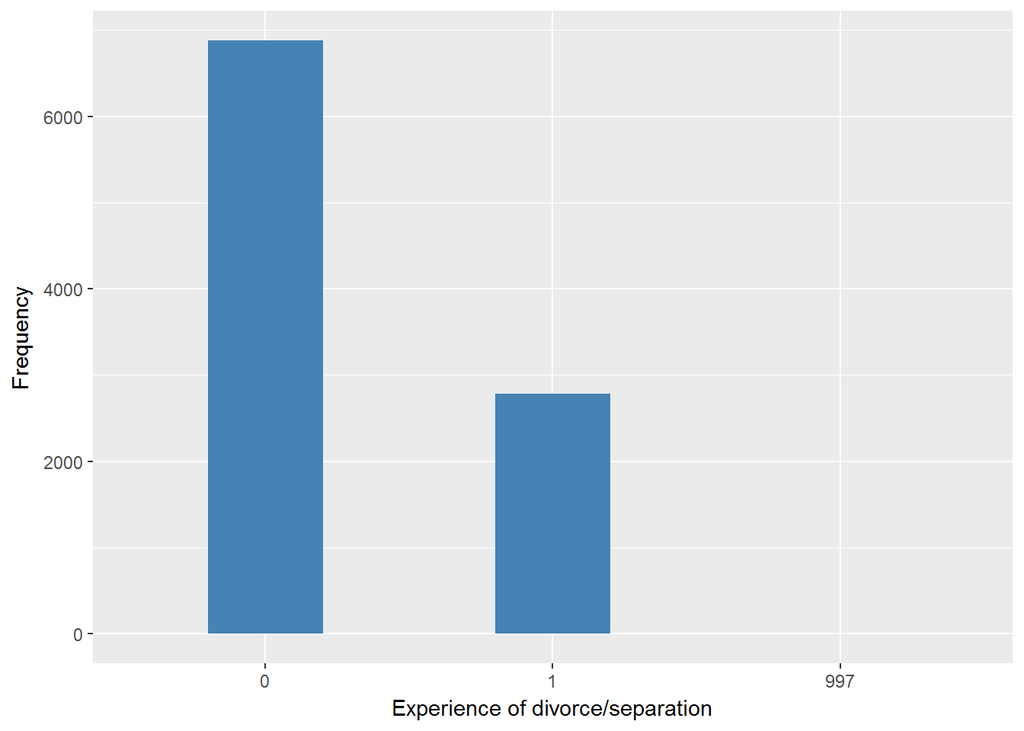

#### 2.1.7.4 Validation

# 3 Quality estimation